# Weight Lifting Exercise

Judy Zhang

2022-08-07

# Overview

Data is collected with 6 participants with 4 wearable sensing devices performing a set of 10 repetitions in 5 different fashions.Information associated with this dataset is accessible via [Internet Archive](http://web.archive.org/web/20161224072740/http:/groupware.les.inf.puc-rio.br/har).

This project quantifies how well each participant does barbell lifting exercise. An ensemble model is trained to classify the sensor inputs to class of move with an accuracy score of above 90%.

# Building Machine Learning Model

## Loading Data and Exploratory Analysis

To get started, the data is loaded and parsed into training and testing set.

```r
url_train <- "https://d396qusza40orc.cloudfront.net/predmachlearn/pml-training.csv"
df <- read.csv(url_train, na.strings = c("NA", "#DIV/0!"))
```

```r
library(caret)
set.seed(1215)
training <- createDataPartition(df$classe, p=0.7, list=F)
train_df <- df[training, ]
test_df <- df[-training,]
cat("training samples: ", nrow(train_df), " testing samples: ", nrow(test_df))
```

```
## training samples:  13737  testing samples:  5885
```

```r
cat("number of columns: ", ncol(train_df))
```

```
## number of columns:  160
```

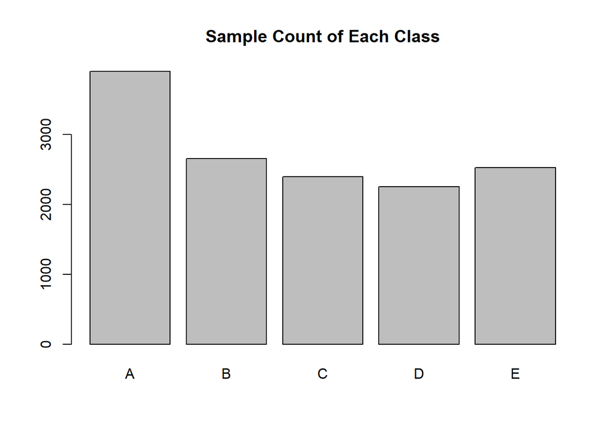

```r
train_df_f <- factor(train_df$classe)
plot(train_df_f, main='Sample Count of Each Class')
```

To reduce the number of features, sparse columns are identified. Threshold is set to 0 and histogram below shows that all of the sparse columns identified have >97% rows with NULL value.

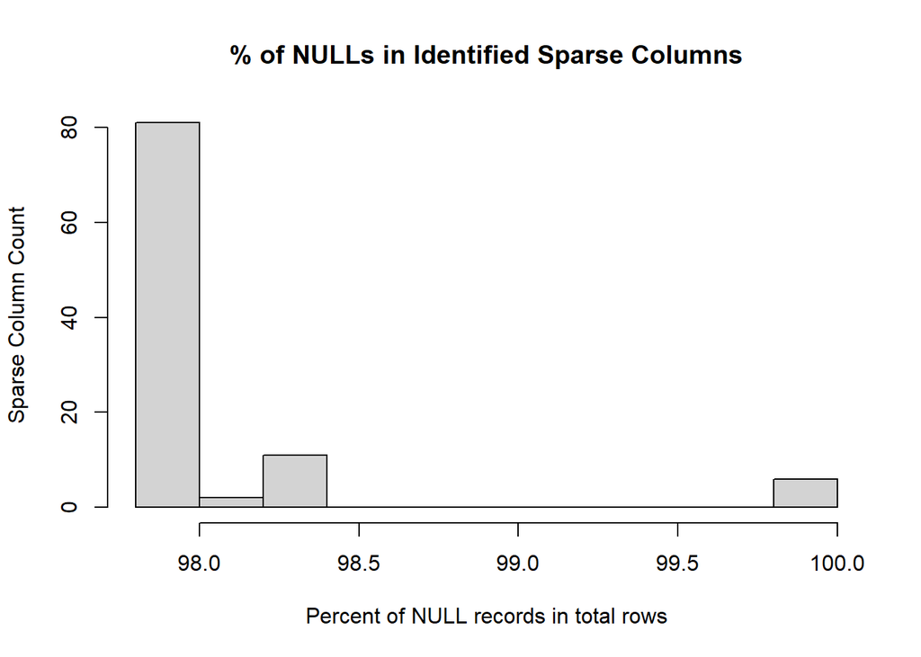

```r
data_cols <- c()
nulls <- c()
for (col in colnames(train_df)){
    null_length <- sum(is.na(train_df[col]))
    if( null_length > 0){
        data_cols <- append(col, data_cols)
        nulls <- append(null_length/(dim(train_df)[1]), nulls)
    }
}
null_cols<-data.frame(data_cols, nulls)
hist(null_cols$nulls*100,
     main="% of NULLs in Identified Sparse Columns",
     xlab="Percent of NULL records in total rows",
     ylab="Sparse Column Count"
     )
```

```r
print(summary(null_cols$nulls))
```

```
##    Min. 1st Qu.  Median    Mean 3rd Qu.    Max.
##  0.9788  0.9788  0.9788  0.9806  0.9794  1.0000
```

```r
cat("Number of sparse columns:" , length(data_cols))
```

```
## Number of sparse columns: 100
```

```r
cat("\nTotal number of columns in original training dataset: " , length(colnames(train_df)))
```

```
##
## Total number of columns in original training dataset:  160
```

## Model Building

Based on dataset document, a model is trained for each sensor. Random forest classifier is used due to its built-in cross validation process and result of high accuracy.

```r
valid_cols <- setdiff(colnames(train_df),null_cols$data_cols)
train_df_trimmed <- train_df[,valid_cols]
sensor_belt <- grep("belt", valid_cols)
sensor_arm <- grep("_arm", valid_cols)
sensor_forearm <-grep("forearm", valid_cols)
sensor_dumbbell <-grep("dumbbell", valid_cols)
cat("belt sensor: ", length(sensor_belt),
    ", arm sensor:", length(sensor_arm),
    ", forearm:", length(sensor_forearm),
    ", dumbbelt", length(sensor_dumbbell)
    )
```

```
## belt sensor:  13 , arm sensor: 13 , forearm: 13 , dumbbelt 13
```

```r
library(caret)
train_df_pred <- train_df
method <- 'rf'
```

```r
belt_data <- train_df_trimmed[, c(names(train_df_trimmed[,sensor_belt]),"classe")]
model_belt <- train(classe~., data=belt_data, method=method)
train_df_pred$belt_pred <- predict(model_belt, belt_data)
```

```r
arm_data <- train_df_trimmed[, c(names(train_df_trimmed[,sensor_arm]),"classe")]
model_arm <- train(classe~., data=arm_data, method=method)
train_df_pred$arm_pred <- predict(model_arm, arm_data)
```

```r
forearm_data <- train_df_trimmed[, c(names(train_df_trimmed[,sensor_forearm]),"classe")]
model_forearm <- train(classe~., data=forearm_data, method=method)
train_df_pred$forearm_pred <- predict(model_forearm, forearm_data)
```

```r
dumbbell_data <- train_df_trimmed[, c(names(train_df_trimmed[,sensor_dumbbell]),"classe")]
model_dumbbell <- train(classe~., data=dumbbell_data, method=method)
train_df_pred$dumbbell_pred <- predict(model_dumbbell, dumbbell_data)
```

Results from each sensor model is merged into the ensemble model.

```r
# Train the ensemble
model <- train(classe ~ belt_pred + arm_pred + forearm_pred + dumbbell_pred, data = train_df_pred, method = "rf")
```

Accuracy score is measure against the test dataset.

```r
test_df_pred <- test_df
test_df_pred$belt_pred <- predict(model_belt, test_df)
test_df_pred$arm_pred <- predict(model_arm, test_df)
test_df_pred$forearm_pred <- predict(model_forearm, test_df)
test_df_pred$dumbbell_pred <- predict(model_dumbbell, test_df)
test_df_pred$pred <- predict(model, test_df_pred)
```

```r
confusionMatrix(as.factor(test_df_pred$pred), as.factor(test_df_pred$classe))
```

```
## Confusion Matrix and Statistics
##
##           Reference
## Prediction    A    B    C    D    E
##          A 1673   77   55  103   23
##          B    1 1060   41    0    3
##          C    0    0  928   34    0
##          D    0    0    2  827    8
##          E    0    2    0    0 1048
##
## Overall Statistics
##
##                Accuracy : 0.9407
##                  95% CI : (0.9344, 0.9466)
##     No Information Rate : 0.2845
##     P-Value [Acc > NIR] : < 2.2e-16
##
##                   Kappa : 0.9245
##
##  Mcnemar's Test P-Value : NA
##
## Statistics by Class:
##
##                      Class: A Class: B Class: C Class: D Class: E
## Sensitivity            0.9994   0.9306   0.9045   0.8579   0.9686
## Specificity            0.9387   0.9905   0.9930   0.9980   0.9996
## Pos Pred Value         0.8664   0.9593   0.9647   0.9881   0.9981
## Neg Pred Value         0.9997   0.9835   0.9801   0.9729   0.9930
## Prevalence             0.2845   0.1935   0.1743   0.1638   0.1839
## Detection Rate         0.2843   0.1801   0.1577   0.1405   0.1781
## Detection Prevalence   0.3281   0.1878   0.1635   0.1422   0.1784
## Balanced Accuracy      0.9691   0.9606   0.9487   0.9279   0.9841
```

# Conclusion

In this project, a machine learning model is developed to classify weight lifting sensor data to various classes of motion. Techniques discussed in the Coursera Practical Machine Learning class are demonstrated in this report.

# References

Ugulino, W.; Cardador, D.; Vega, K.; Velloso, E.; Milidiu, R.; Fuks, H. Wearable Computing: Accelerometers’ Data Classification of Body Postures and Movements. Proceedings of 21st Brazilian Symposium on Artificial Intelligence. Advances in Artificial Intelligence - SBIA 2012. In: Lecture Notes in Computer Science. , pp. 52-61. Curitiba, PR: Springer Berlin / Heidelberg, 2012. ISBN 978-3-642-34458-9. DOI: 10.1007/978-3-642-34459-6_6.